# Tuberculosis report from 2000 - 2020

## Explanatory Data Analysis

### Question 1: What has been the trend of tuberculosis cases from 2000 to 2020?

Which year has the highest tuberculosis cases?

```r
by_year <- tuber %>%
  group_by(.,year) %>%
  summarise(., total_cases = sum(cases))
```

```r
kable(by_year)
```

| year | total_cases |
| --- | --- |
| 2000 | 1148524 |
| 2001 | 1237444 |
| 2002 | 1523369 |
| 2003 | 1860645 |
| 2004 | 2184958 |
| 2005 | 2364897 |
| 2006 | 3064892 |
| 2007 | 3933707 |
| 2008 | 3680748 |
| 2009 | 3932522 |
| 2010 | 4295276 |
| 2011 | 4390442 |
| 2012 | 4377419 |
| 2013 | 3422746 |
| 2014 | 5674335 |
| 2015 | 6041262 |
| 2016 | 6524581 |
| 2017 | 6536013 |
| 2018 | 7202478 |
| 2019 | 8237527 |
| 2020 | 6937404 |

plotting the trend of tuberculosis cases by year

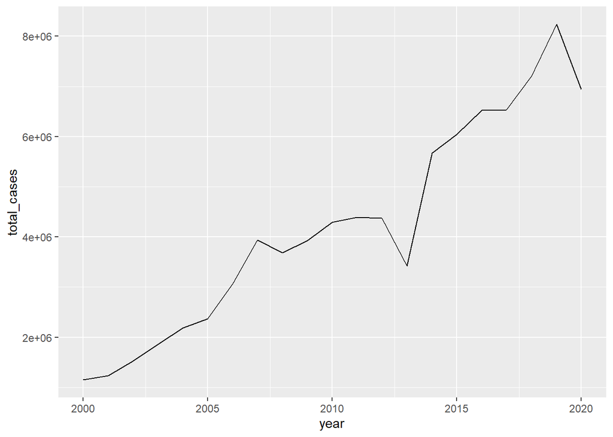

```r
by_year %>%
  ggplot(aes (x = year)) +
  geom_line(aes(y = total_cases))
```

The year with the highest tuberculosis cases

```r
#What year has the highest number of tuberculosis cases?
by_year %>%
  arrange(desc(total_cases)) %>%
  head(1)
```

```
## # A tibble: 1 × 2
##    year total_cases
##   <dbl>       <dbl>
## 1  2019     8237527
```

### Question 2: What is the trend of tuberculosis cases in countries across the globe?

What are the 10 countries with the top tuberculosis cases? What are the 10 countries with the least tuberculosis cases?

```r
# grouping cases by country
by_country <- tuber %>%
  group_by(.,country) %>%
  summarise(., total_cases = sum(cases))
```